# Biostat 202B Homework 3

Due April 30, 2024 @ 11:59PM

Author

Hanbei Xiong 605257780

# Question 1

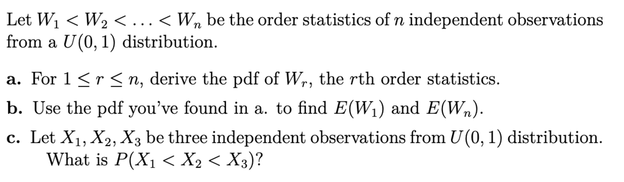

**(a) Answer:**

By definition, we know the pdf of ith order statistic is:

$f_{W_i}(x)=\frac{n!}{(i-1)!(n-i)!}F_X(x)^{i-1}(1-F_X(x))^{n-i}f_X(x)$

Since $X_i \sim U(0,1)$

$f(x)=1$ for $0\leq x \leq 1$

$F(x)=x$ for $0\leq x \leq 1$

$f_{W_r}(x)=\frac{n!}{(i-1)!(n-r)!}x^{r-1}(1-x)^{n-r}$ for $0\leq x \leq 1$

**(b) Answer:**

$E[W_1]=\int_{0}^{1}w\frac{n!}{(1-1)!(n-1)!}w^{1-1}(1-w)^{n-1}dw=\int_{0}^{1}nw(1-w)^{n-1}dw=\frac{1}{n+1}$

$E[W_n]=\int_{0}^{1}w\frac{n!}{(n-1)!(n-n)!}w^{n-1}(1-w)^{n-n}dw=\int_{0}^{1}nw^{n}dw=\frac{n}{n+1}$

**(c) Answer:**

There are only 3! combinations of cases to form the order.

Therefore, $P(X_1<X_2<X_3)=\frac{1}{6}$

# Question 2

**Answer:**
$$\begin{align*}
f_{Y(i),Y(j)}(y,z)&=lim_{\Delta y\to \infty, \Delta z\to \infty}\frac{P(\text{i-1 }Y_t's<y, \text{ one }Y_t\in (y,y+\Delta y),\text{ j-i-1 }Y_t's >y+\Delta y \text{ and }<z, \text{ one }Y_t\in (z,z+\Delta z),\text{ n-j } Y_t's >z+\Delta z)}{\Delta y \Delta z}\\
&={n \choose i-1}{n-i+1 \choose j-i-1}{n-i+1-j+i+1 \choose n-j}F_X(y)^{i-1}\{F_X{(z)-F_X(y)}\}^{j-i-1}\{1-F_X(z)\}^{n-j}f_X(y)f_X(z)\\
&=\frac{n!}{(i-1)!(j-i-1)!(n-j)!}F_X(y)^{i-1}\{F_X{(z)-F_X(y)}\}^{j-i-1}\{1-F_X(z)\}^{n-j}f_X(y)f_X(z) \text{, for} -\infty<y<z<\infty
\end{align*}$$

# Question 3

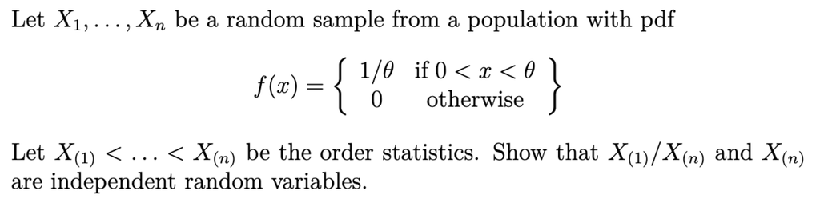

**Answer:**

Let $V=\frac{X_{(1)}}{X_{(n)}}$, $R = X_{(n)}$

Then, $X_{(1)}=RV$, $X_{(n)}=R$

$J(V,R)=\begin{vmatrix} \frac{\partial X_{(1)}}{\partial V} & \frac{\partial X_{(1)}}{\partial R} \\ \frac{\partial X_{(n)}}{\partial V} & \frac{\partial X_{(n)}}{\partial R} \end{vmatrix}=\begin{vmatrix} R & V \\ 0 & 1 \end{vmatrix}=R$

$$\begin{align*}
f_{V,R}(v,r)&=f_{X_{(1)},X_{(n)}}(rv,r)|J(v,r)|\\
&=f_{X_{(1)},X_{(n)}}(rv,r)r\\
&=\frac{n!}{(n-2)!}\{F_X{(r)-F_X(rv)}\}^{n-2}f_X(rv)f_X(r)r\\
&=\frac{n!}{(n-2)!}(\frac{r}{\theta}-\frac{rv}{\theta})^{n-2}\frac{r}{\theta^2}\\
&=\frac{n!}{(n-2)!}\frac{r^{n-1}}{\theta^n}(1-v)^{n-2}\text{, for } 0<r<\theta \text{, } 0<v<1
\end{align*}$$

Since $f_{V,R}(v,r)=f_V(v)f_R(r) \text{, for } 0<r<\theta \text{, } 0<v<1$, V and R are independent

Hence, $\frac{X_{(1)}}{X_{(n)}} \perp X_{(n)}$

# Question 4

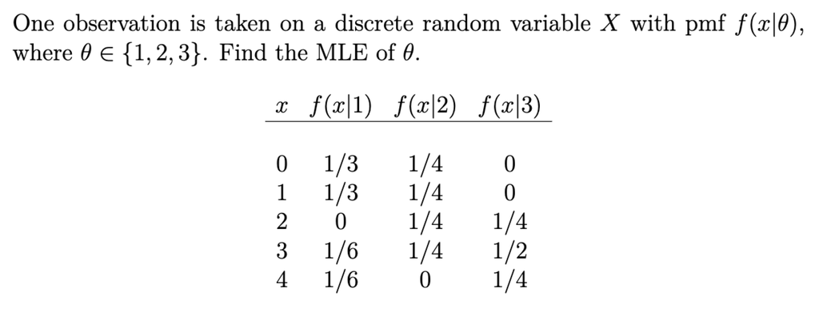

**Answer:**

This is non regular model since $f(x;\theta)\geq 0$

For $X = 0$: The MLE of $\theta$ is 1 since $f(0 | 1) = \frac{1}{3}$ is the largest probability of observing $X = 0$.

For $X = 1$: Similarly, the MLE of $\theta$ is 1.

For $X = 2$: The MLE of $\theta$ is 2 or 3, as both $f(2 | 2)$ and $f(2 | 3)$ are $\frac{1}{4}$.

For $X = 3$: The MLE of $\theta$ is 3 since $f(3 | 3) = \frac{1}{2}$ is the largest.

For $X = 4$: The MLE of $\theta$ is 3 as well since $f(4 | 3) = \frac{1}{4}$ is the largest